# Regressão Logística e validação de suposições

# Import

Importanto bibliotecas

```r
library(data.table)
library(tidyverse)
library(recipes)
library(customsteps)
library(arrow)
library(explore)
library(car)
```

```r
library(ggplot2)
library(dbscan)
library(scales)
library(caret)
library(ROCR)
library(cluster)
library(FastKNN)
```

Lendo arquivo para aplicação da regressão

```r
comorbidades_regressao <- as.data.table(read_parquet("../data/interim/comorbidades_regressao.parquet"))
comorbidade_regressao_simples_total <- as.data.table(
                                                read_parquet("../data/interim/comorbidades_regressao_nao_duplicatas_simples.parquet")
                                                )
comorbidade_regressao_simples_copia <- copy(comorbidade_regressao_simples_total)
df_comor_simples <- as.data.table(read_parquet("../data/interim/comorbidade_simples.parquet"))
```

Separando os dados em treino e teste do modelo

```r
set.seed(412)
index_treino <- createDataPartition(comorbidade_regressao_simples_total$obito_pre,p = .7,list = F)
comorbidade_regressao_simples <- comorbidade_regressao_simples_total[index_treino]
comorbidade_regressao_simples_teste <- comorbidade_regressao_simples_total[-index_treino]
```

Este arquivo importado possui classes de caracteres, então vamos fazer a conversão para factor do Python

```r
describe(comorbidade_regressao_simples)
```

| variable | type | na | na_pct | unique | min | mean | max |
| --- | --- | --- | --- | --- | --- | --- | --- |
| cs_sexo_pre | chr | 0 | 0 | 2 | NA | NA | NA |
| asma_pre | chr | 0 | 0 | 3 | NA | NA | NA |
| cardiopatia_pre | chr | 0 | 0 | 3 | NA | NA | NA |
| diabetes_pre | chr | 0 | 0 | 3 | NA | NA | NA |
| doenca_hematologica_pre | chr | 0 | 0 | 3 | NA | NA | NA |
| doenca_hepatica_pre | chr | 0 | 0 | 3 | NA | NA | NA |
| doenca_neurologica_pre | chr | 0 | 0 | 3 | NA | NA | NA |
| doenca_renal_pre | chr | 0 | 0 | 3 | NA | NA | NA |
| imunodepressao_pre | chr | 0 | 0 | 3 | NA | NA | NA |
| obesidade_pre | chr | 0 | 0 | 3 | NA | NA | NA |

[output cut: 7 more lines]

# Tratamento dos dados

Conversão em factor

```r
colunas_factor <- as.data.table(describe(comorbidade_regressao_simples))[type == "chr",]$variable
comorbidade_regressao_simples[,(colunas_factor) := lapply(.SD,
                                                          function(x){
                                                              as.factor(x)
                                                          }),
                              .SDcols = colunas_factor,
                             ][,c("__index_level_0__") := NULL]

comorbidade_regressao_simples[,obito_pre := factor(obito_pre,levels = c(0,1), labels = c("vivo","morto"))]
```

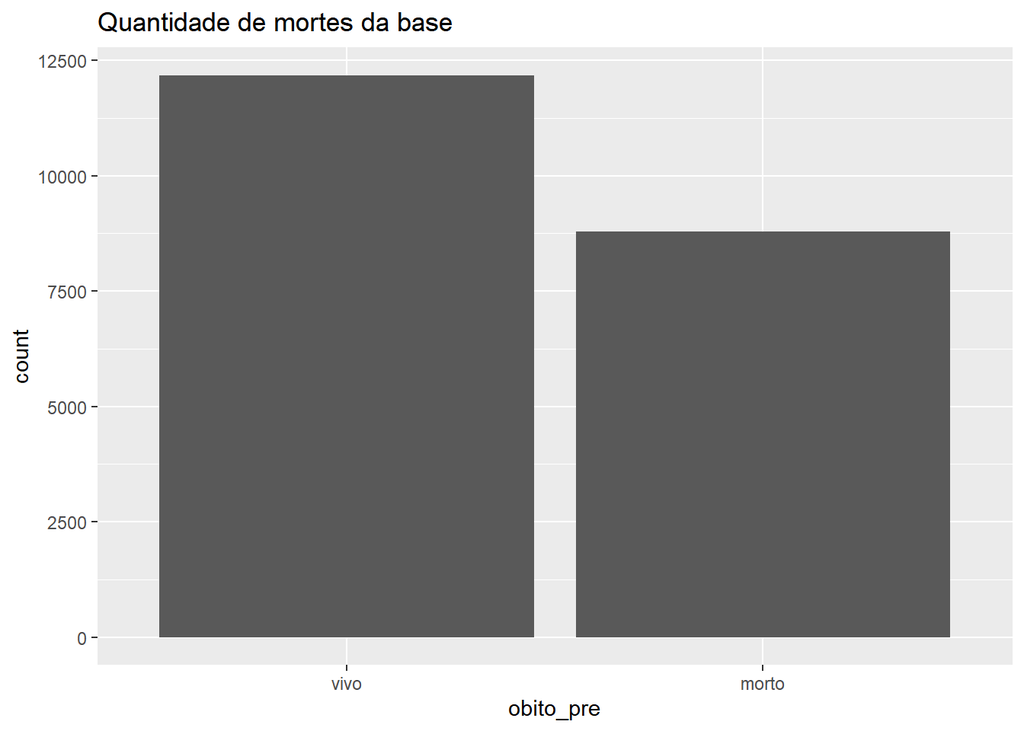

```r
ggplot(comorbidade_regressao_simples) + geom_bar(aes(x = obito_pre)) + ggtitle("Quantidade de mortes da base")
```

```r
comorbidade_regressao_simples[,.N,by = .(obito_pre)
                             ][,.("obito_pre" = get("obito_pre"),
                                  "percentual" = N/sum(N))]
```

| obito_pre | percentual |
| --- | --- |
| vivo | 0.5809051 |
| morto | 0.4190949 |

Agora, só precisamos normalizar os dados da idade

```r
describe(comorbidade_regressao_simples)
```

| variable | type | na | na_pct | unique | min | mean | max |
| --- | --- | --- | --- | --- | --- | --- | --- |
| cs_sexo_pre | fct | 0 | 0 | 2 | NA | NA | NA |
| asma_pre | fct | 0 | 0 | 3 | NA | NA | NA |
| cardiopatia_pre | fct | 0 | 0 | 3 | NA | NA | NA |
| diabetes_pre | fct | 0 | 0 | 3 | NA | NA | NA |
| doenca_hematologica_pre | fct | 0 | 0 | 3 | NA | NA | NA |
| doenca_hepatica_pre | fct | 0 | 0 | 3 | NA | NA | NA |
| doenca_neurologica_pre | fct | 0 | 0 | 3 | NA | NA | NA |
| doenca_renal_pre | fct | 0 | 0 | 3 | NA | NA | NA |
| imunodepressao_pre | fct | 0 | 0 | 3 | NA | NA | NA |
| obesidade_pre | fct | 0 | 0 | 3 | NA | NA | NA |

[output cut: 6 more lines]

```r
ss <- scale(comorbidade_regressao_simples$idade_pre)
comorbidade_regressao_simples$idade_pre <- ss

desvio <- attributes(ss)$`scaled:scale`
media <- attributes(ss)$`scaled:center`
```

Criando o Pipeline por meio das recipes

```r
pipeline <- recipe(x=comorbidade_regressao_simples_total[index_treino])%>%
                step_rm("__index_level_0__") %>%
                  step_string2factor(-c("idade_pre","obito_pre")) %>%
                    step_normalize("idade_pre") %>%
                    step_num2factor("obito_pre",transform = function(x) x + 1,levels = c("vivo","morto"))
```

# Primeiro modelo

Criando o primeiro modelo, utilizando todas as variáveis

```r
log_reg <- glm(formula = obito_pre ~ .,
               family = binomial(link="logit"),
               data = comorbidade_regressao_simples,
               x = T)
summary(log_reg)
```

```
##
## Call:
## glm(formula = obito_pre ~ ., family = binomial(link = "logit"),
##     data = comorbidade_regressao_simples, x = T)
##
## Deviance Residuals:
##     Min       1Q   Median       3Q      Max
## -1.6293  -1.0409  -0.7333   1.1766   2.1662
##
## Coefficients:
##                                 Estimate Std. Error z value Pr(>|z|)
## (Intercept)                    -0.727994   0.045361 -16.049  < 2e-16 ***
## cs_sexo_premasculino            0.157404   0.029401   5.354 8.62e-08 ***
## asma_prenão                    -0.156024   0.073283  -2.129 0.033248 *
## asma_presim                    -0.603095   0.068528  -8.801  < 2e-16 ***
## cardiopatia_prenão              0.043857   0.057855   0.758 0.448426
## cardiopatia_presim              0.095295   0.044334   2.149 0.031597 *
## diabetes_prenão                 0.001982   0.056617   0.035 0.972072
## diabetes_presim                 0.044054   0.044187   0.997 0.318761
## doenca_hematologica_prenão      0.210647   0.097333   2.164 0.030449 *
## doenca_hematologica_presim      0.175451   0.094227   1.862 0.062601 .
## doenca_hepatica_prenão          0.349539   0.090773   3.851 0.000118 ***
## doenca_hepatica_presim          0.434351   0.087130   4.985 6.19e-07 ***
## doenca_neurologica_prenão      -0.177621   0.067988  -2.613 0.008987 **
## doenca_neurologica_presim       0.096874   0.057508   1.685 0.092081 .
## doenca_renal_prenão            -0.096304   0.060795  -1.584 0.113179
## doenca_renal_presim             0.094263   0.051554   1.828 0.067483 .
## imunodepressao_prenão          -0.182370   0.068476  -2.663 0.007739 **
## imunodepressao_presim          -0.112993   0.056968  -1.983 0.047317 *
## obesidade_prenão                0.271437   0.051877   5.232 1.67e-07 ***
## obesidade_presim                0.431154   0.048440   8.901  < 2e-16 ***
## outros_fatores_de_risco_prenão  0.173714   0.045192   3.844 0.000121 ***
## outros_fatores_de_risco_presim  0.348117   0.035383   9.839  < 2e-16 ***
## pneumopatia_prenão             -0.066740   0.070562  -0.946 0.344232
## pneumopatia_presim              0.108820   0.057818   1.882 0.059820 .
## puerpera_prenão                 0.026030   0.057779   0.451 0.652343
## puerpera_presim                -0.530407   0.247836  -2.140 0.032343 *
## sindrome_de_down_prenão        -0.248988   0.107510  -2.316 0.020561 *
## sindrome_de_down_presim        -0.146282   0.166330  -0.879 0.379147
## idade_pre                       0.467381   0.016776  27.859  < 2e-16 ***
## ---
## Signif. codes:  0 '***' 0.001 '**' 0.01 '*' 0.05 '.' 0.1 ' ' 1
##
## (Dispersion parameter for binomial family taken to be 1)
##
##     Null deviance: 28518  on 20968  degrees of freedom
## Residual deviance: 26939  on 20940  degrees of freedom
## AIC: 26997
##
## Number of Fisher Scoring iterations: 4
```

Vamos ver como foram os resultados na base de treinamento

```r
treino.prob <- predict(log_reg,comorbidade_regressao_simples,type = "response")
limiar <- 0.5

confusionMatrix(data = factor(as.integer(treino.prob > limiar),levels = c(0,1), labels = c("vivo","morto")),
                reference = comorbidade_regressao_simples$obito_pre,
                positive = "morto",
                mode = "everything")
```

```
## Confusion Matrix and Statistics
##
##           Reference
## Prediction vivo morto
##      vivo  9436  5229
##      morto 2745  3559
##
##                Accuracy : 0.6197
##                  95% CI : (0.6131, 0.6263)
##     No Information Rate : 0.5809
##     P-Value [Acc > NIR] : < 2.2e-16
##
##                   Kappa : 0.187
##
##  Mcnemar's Test P-Value : < 2.2e-16
##
##             Sensitivity : 0.4050
##             Specificity : 0.7746
##          Pos Pred Value : 0.5646
##          Neg Pred Value : 0.6434
##               Precision : 0.5646
##                  Recall : 0.4050
##                      F1 : 0.4716
##              Prevalence : 0.4191
##          Detection Rate : 0.1697
##    Detection Prevalence : 0.3006
##       Balanced Accuracy : 0.5898
##
##        'Positive' Class : morto
##
```

```r
teste <- as.data.table(pipeline%>%prep()%>%bake(comorbidade_regressao_simples_teste))

matriz_confusao <- function(df,modelo,threshold = 0.5){
  df.prob <- predict(modelo,df,type = "response")

  return(confusionMatrix(data = factor(as.integer(df.prob > threshold),levels = c(0,1), labels = c("vivo","morto")),
                reference = df$obito_pre,
                positive = "morto",
                mode = "everything"))
}
matriz_confusao(teste,log_reg,limiar)
```

```
## Confusion Matrix and Statistics
##
##           Reference
## Prediction vivo morto
##      vivo  4028  2280
##      morto 1181  1497
##
##                Accuracy : 0.6148
##                  95% CI : (0.6047, 0.6249)
##     No Information Rate : 0.5797
##     P-Value [Acc > NIR] : 6.394e-12
##
##                   Kappa : 0.1767
##
##  Mcnemar's Test P-Value : < 2.2e-16
##
##             Sensitivity : 0.3963
##             Specificity : 0.7733
##          Pos Pred Value : 0.5590
##          Neg Pred Value : 0.6386
##               Precision : 0.5590
##                  Recall : 0.3963
##                      F1 : 0.4638
##              Prevalence : 0.4203
##          Detection Rate : 0.1666
##    Detection Prevalence : 0.2980
##       Balanced Accuracy : 0.5848
##
##        'Positive' Class : morto
##
```

Curva ROC

```
## [1] "AUC =  0.651"
```

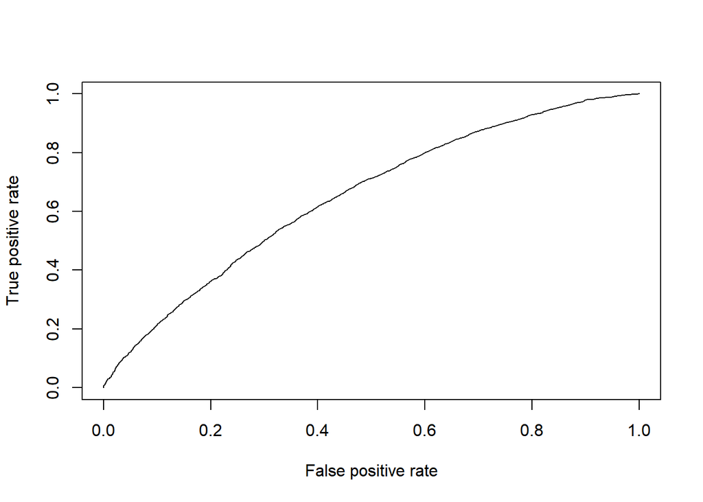

```r
calcula_roc <- function(df,modelo,threshold = 0.5){
     p <- predict(modelo,df,type = "response")

     pr <- prediction(predictions = p,
                       labels = df$obito_pre,
                       label.ordering = c("vivo","morto"))

     prf <- performance(pr, measure = "tpr", x.measure = "fpr")

     auc <- performance(pr, measure = "auc")
     print(paste("AUC = ",round(auc@y.values[[1]],3),sep=" "))
     plot(prf)
}



calcula_roc(df = teste,modelo = log_reg)
```

# Análise residual e de influência do primeiro modelo

doi: 10.21037/atm.2016.03.36

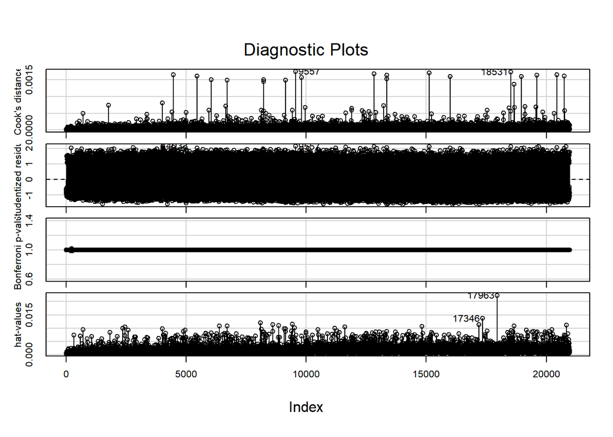

```r
influenceIndexPlot(log_reg)
```

Neste gráfico, temos os resíduos studentizados no eixo y (quanto maior seu valor, mais provável de ser um outlier), o hat-value no eixo x e o tamanho do círculo representa a distância de Cook (maior o raio, maior a distância). Vemos, portanto, que existe um indivíduo que está bem fora do padrão (o mesmo 17963)

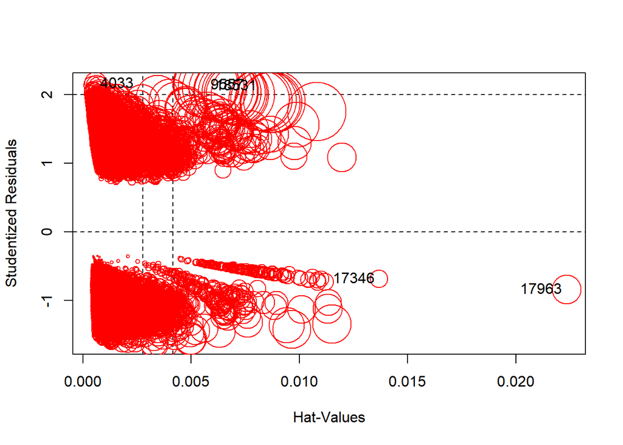

|  | StudRes | Hat | CookD |
| --- | --- | --- | --- |
| 4033 | 2.1674721 | 0.000588037 | 0.0001917569 |
| 9557 | 2.1503122 | 0.005691520 | 0.0017551645 |
| 17346 | -0.6823871 | 0.013675312 | 0.0001259763 |
| 17963 | -0.8368365 | 0.022342086 | 0.0003325698 |
| 18531 | 2.1304190 | 0.005907885 | 0.0017385846 |

```r
influencePlot(log_reg,col='red')
```

Este indivíduo é aquele que não morreu, mas possui várias comorbidades (provavelmente trata-se de um erro)

```r
comorbidade_regressao_simples[17963,]
```

| cs_sexo_pre | asma_pre | cardiopatia_pre | diabetes_pre | doenca_hematologica_pre | doenca_hepatica_pre | doenca_neurologica_pre | doenca_renal_pre | imunodepressao_pre | obesidade_pre | outros_fatores_de_risco_pre | pneumopatia_pre | puerpera_pre | sindrome_de_down_pre | idade_pre | obito_pre |
| --- | --- | --- | --- | --- | --- | --- | --- | --- | --- | --- | --- | --- | --- | --- | --- |
| feminino | sim | sim | sim | sim | sim | sim | sim | sim | sim | não | sim | sim | sim | -0.8953702 | vivo |

Vejamos se existem outros casos de indivíduos que possuem a sindrome e no campo “puérpera”, foram classificados como “sim”

```r
#São os dois os indivíduos na base de treino que estão equivocados. Necessitaremos removê-los em modelos futuros
linhas_outlier <- comorbidade_regressao_simples[,.I[puerpera_pre == 'sim' & sindrome_de_down_pre == 'sim']]
comorbidade_regressao_simples[puerpera_pre == 'sim' & sindrome_de_down_pre == 'sim',]
```

| cs_sexo_pre | asma_pre | cardiopatia_pre | diabetes_pre | doenca_hematologica_pre | doenca_hepatica_pre | doenca_neurologica_pre | doenca_renal_pre | imunodepressao_pre | obesidade_pre | outros_fatores_de_risco_pre | pneumopatia_pre | puerpera_pre | sindrome_de_down_pre | idade_pre | obito_pre |
| --- | --- | --- | --- | --- | --- | --- | --- | --- | --- | --- | --- | --- | --- | --- | --- |
| feminino | não | não | não | não | não | não | não | não | não | sim | não | sim | sim | -1.0469720 | vivo |
| feminino | sim | sim | sim | sim | sim | sim | sim | sim | sim | não | sim | sim | sim | -0.8953702 | vivo |

Podemos montar o gráfico de influência da seguinte forma, com o auxilio do ggplot2

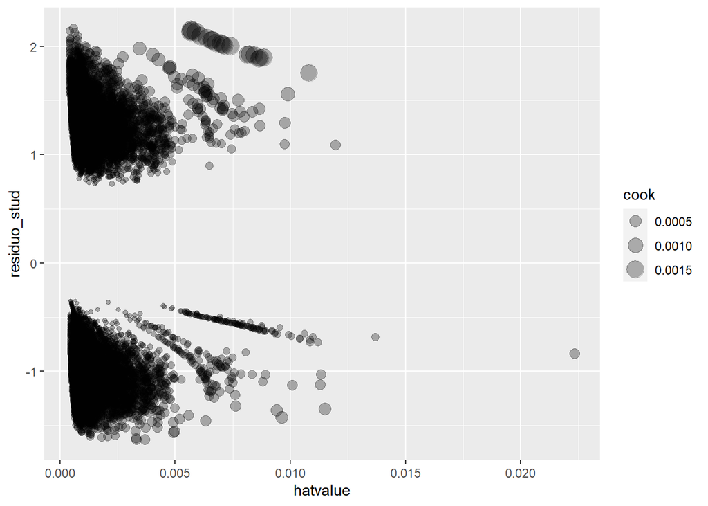

```r
grafico_influencia <- function(model,size=TRUE){
          df_influencia <- data.table(residuo_stud = rstudent(model),
                                 hatvalue = hatvalues((model)),
                                 cook = cooks.distance(model))
          if(size == TRUE){
            plotagem <- ggplot(df_influencia) + geom_point(aes(x = hatvalue, y=residuo_stud, size = cook),alpha = 0.3)
          }else{
            plotagem <- ggplot(df_influencia) + geom_point(aes(x = hatvalue, y=residuo_stud),alpha = 0.3)
          }

          return(list("df_influencia" = df_influencia,
                      "plot" = plotagem))
}
result <- grafico_influencia(log_reg)
influ_df <- result$df_influencia
result$plot
```

Nota-se a presença de grupos distintos no gráfico acima de influência. Vamos fazer uma clusterização para montar grupos e criar algumas estatíticas básicas. Utilizaremos o algorimo DBScan para fazer o agrupamento, mas para termos eficiencia no método, precisamos, primeiramente, normalizar os dados, para que estejam na mesma escala

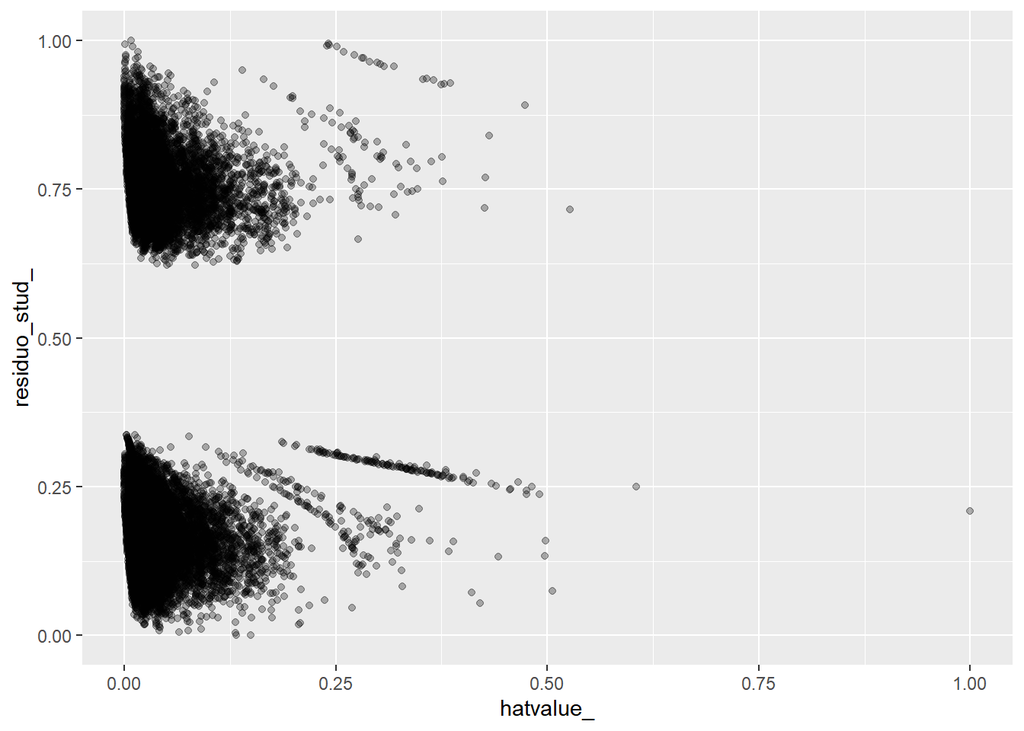

```r
normalize <- function(x, na.rm = TRUE) {
    return((x- min(x)) /(max(x)-min(x)))
}

influ_df[,`:=`(hatvalue_ = normalize(hatvalue),residuo_stud_ = normalize(residuo_stud))]
ggplot(influ_df) + geom_point(aes(x = hatvalue_, y=residuo_stud_),alpha = 0.3)
```

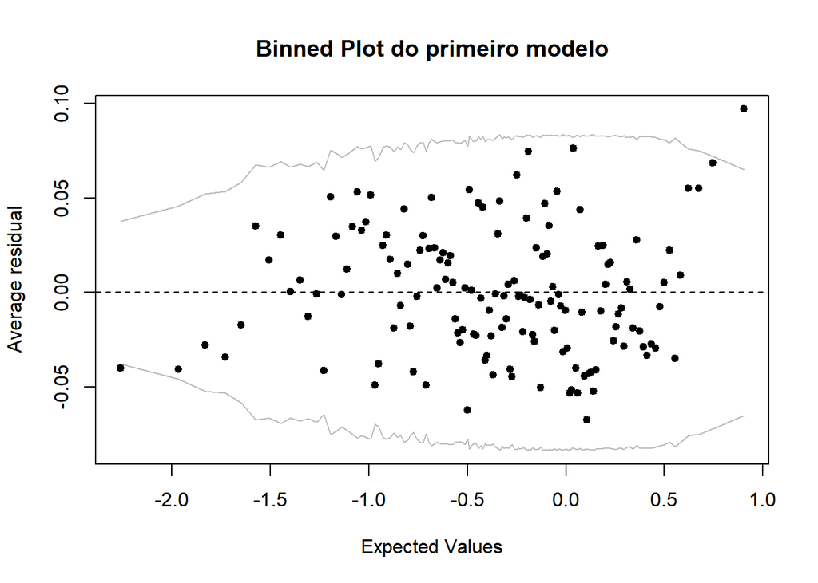

```r
arm::binnedplot(predict(log_reg),resid(log_reg,type = "response"),main = "Binned Plot do primeiro modelo")
```

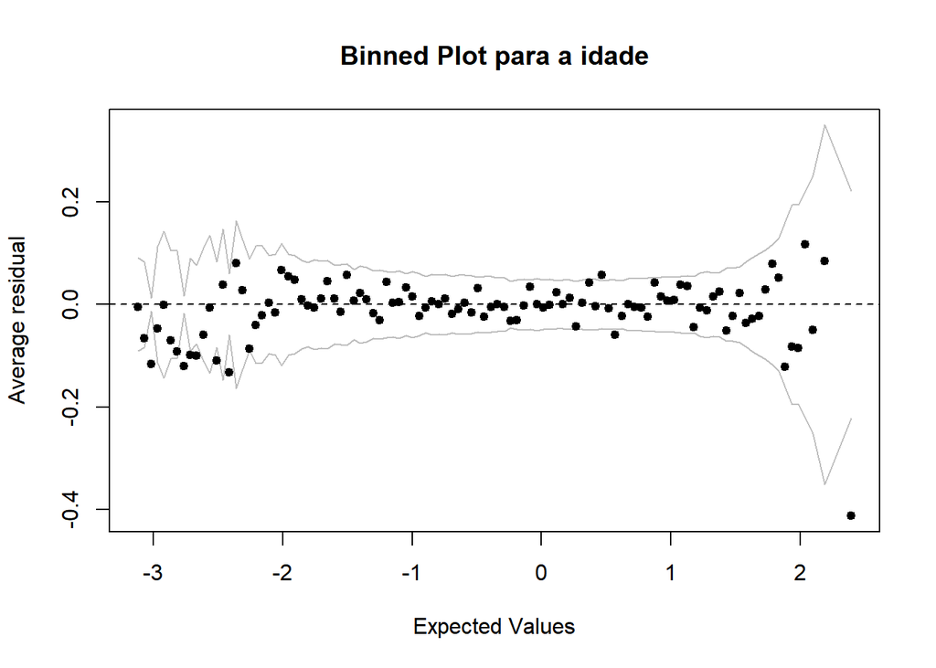

```r
arm::binnedplot(comorbidade_regressao_simples$idade_pre,residuals(log_reg,type = "response"),
                nclass = 2000,main = "Binned Plot para a idade")
```

## Análise de clusters do gráfico de resíduo por influência

O resultado do modelo DBScan é apresentado abaixo

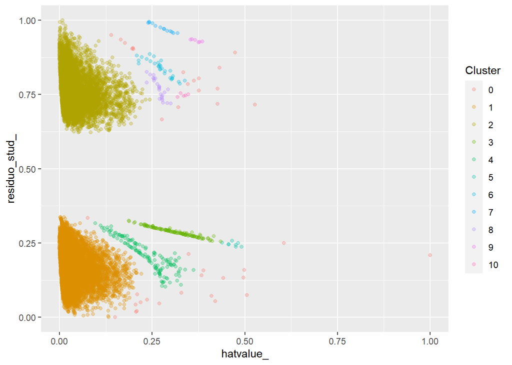

```r
db_result <- dbscan(x = as.matrix(influ_df[,.(hatvalue_,residuo_stud_)]), eps = 0.0233)
ggplot(influ_df) + geom_point(aes(x = hatvalue_, y=residuo_stud_, color = as.factor(db_result$cluster)),alpha = 0.3) +
  guides(color=guide_legend(title="Cluster"))
```

O modelo DBScan classificou alguns pontos (classificados no grupo 0) como outlier. Dessa forma, vamos considerar os grupos que são nítidos, visivelmente (6 grupos)

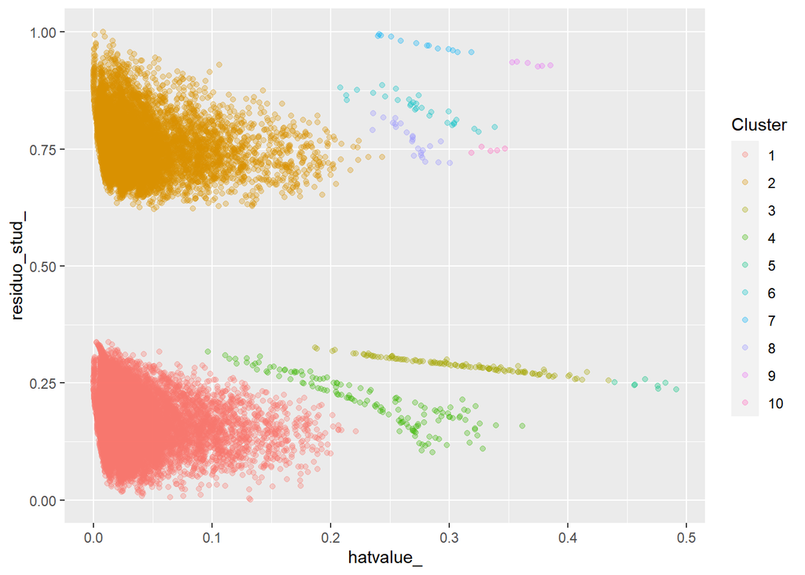

```r
#Visualmente, iremos contruir 6 grupos
influ_df[,cluster := db_result$cluster]
ggplot(influ_df[(cluster <= 5 & cluster != 0) |
                (cluster == 9  | cluster == 6   | cluster == 7 | cluster == 11 | cluster == 10) |
                ( cluster == 12| cluster == 8)]) +
  geom_point(aes(x = hatvalue_, y=residuo_stud_, color = as.factor(cluster)),alpha = 0.3) +
  guides(color=guide_legend(title="Cluster"))
```

Os 6 grupos podem ser vistos no gráfico abaixo

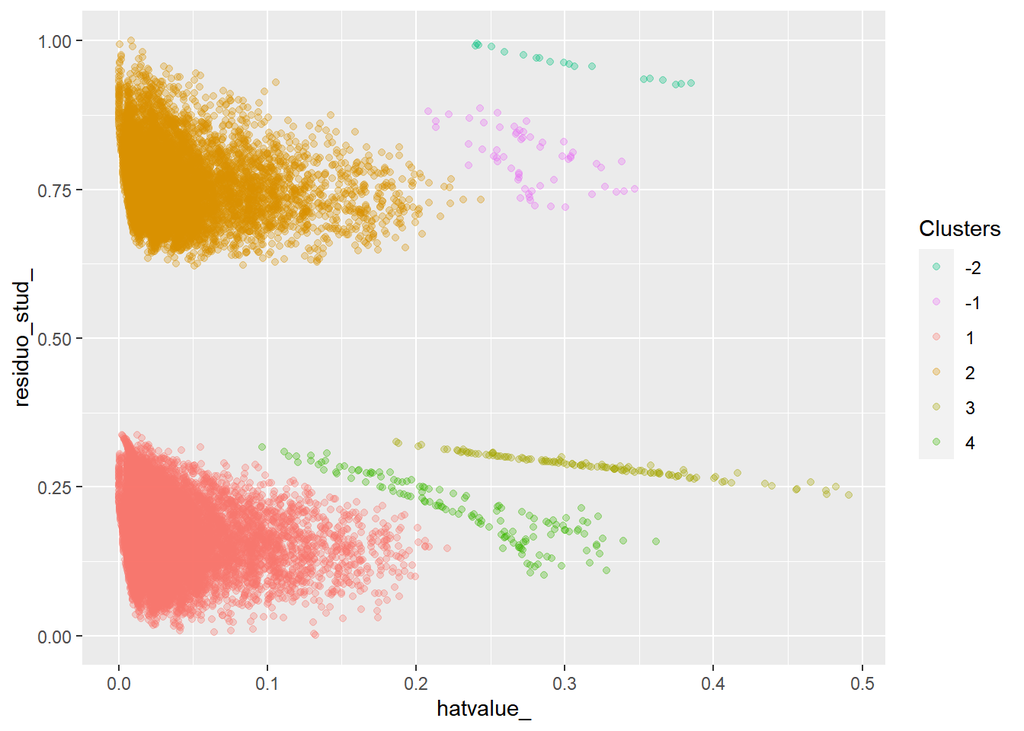

```r
cores <- hue_pal()(length(
                  unique(
                    influ_df[(cluster <= 5 & cluster != 0) |
                              (cluster == 9  | cluster == 6   | cluster == 7 | cluster == 11 | cluster == 10) |
                              ( cluster == 12| cluster == 8)]$cluster
                      )
                  ))
comorbidade_regressao_simples[,cluster := db_result$cluster,
                             ][,cluster := fifelse(cluster == 8 | cluster == 6| cluster == 10,
                                                   -1,
                                                   fifelse((cluster == 9 | cluster == 7),
                                                           -2,
                                                           fifelse(cluster == 5,
                                                                   3,
                                                                   cluster)))]

influ_df[,cluster := db_result$cluster,
       ][,cluster := fifelse(cluster == 8 | cluster == 6| cluster == 10,
                                                   -1,
                                                   fifelse((cluster == 9 | cluster == 7),
                                                           -2,
                                                           fifelse(cluster == 5,
                                                                   3,
                                                                   cluster)))
       ][,obito_pre := comorbidade_regressao_simples$obito_pre]


ggplot(influ_df[(cluster != 0)]) +
  geom_point(aes(x = hatvalue_, y=residuo_stud_, color = as.factor(cluster)),alpha = 0.3) +
    scale_color_manual(values = c(cores[5],cores[9],cores[1],cores[2],cores[3],cores[4])) +
       guides(color=guide_legend(title="Clusters"))
```

O grupo abaixo do valor 0.5 para os resíduos são todos aqueles que não morreram (em vermelho), enquanto que os acima (em azul), são aqueles que morreram

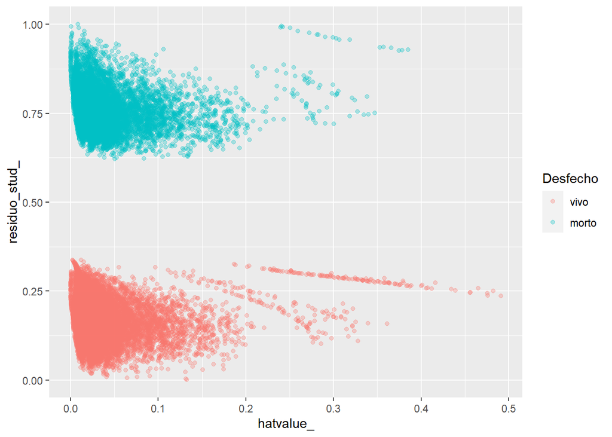

```r
ggplot(influ_df[(cluster  != 0)]) +
  geom_point(aes(x = hatvalue_, y=residuo_stud_, color = as.factor(obito_pre)),alpha = 0.3) +
     guides(color=guide_legend(title="Desfecho"))
```

Os clusters que separamos, é composto em grande parte, de pessoas que viveram

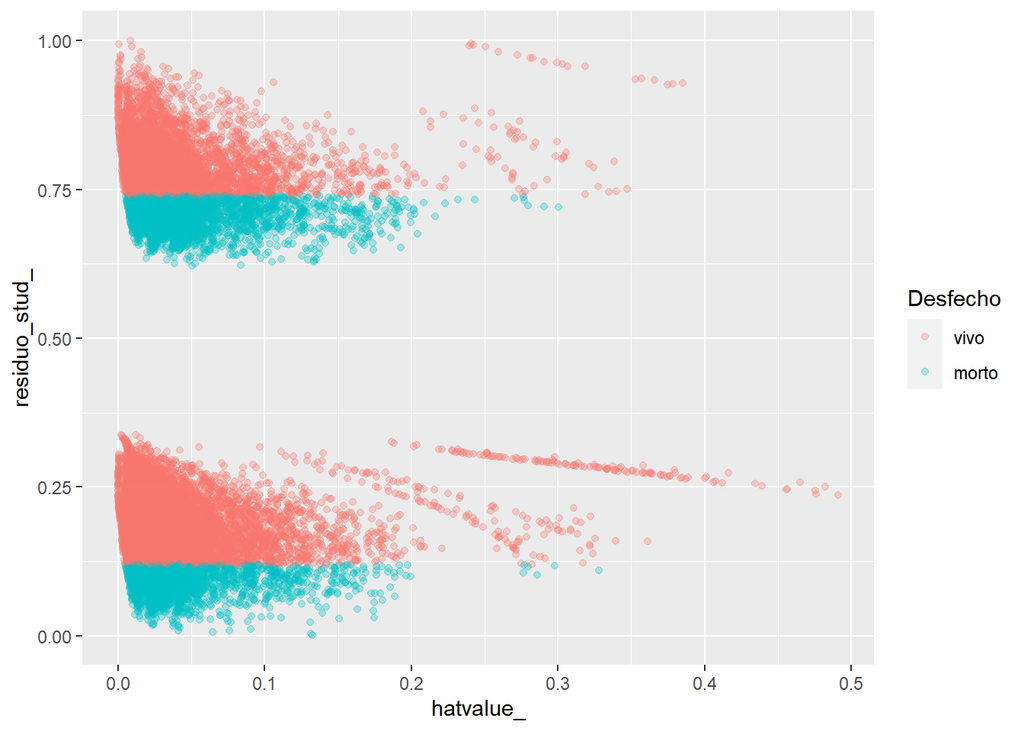

```r
ggplot(influ_df[(cluster  != 0)]) +
  geom_point(aes(x = hatvalue_,
                 y=residuo_stud_,
                 color = factor(as.integer(predict(log_reg,
                                                   comorbidade_regressao_simples[(cluster  != 0)],
                                                   type = "response") > limiar),levels = c(0,1), labels = c("vivo","morto"))),
             alpha = 0.3)  + guides(color=guide_legend(title="Desfecho"))
```

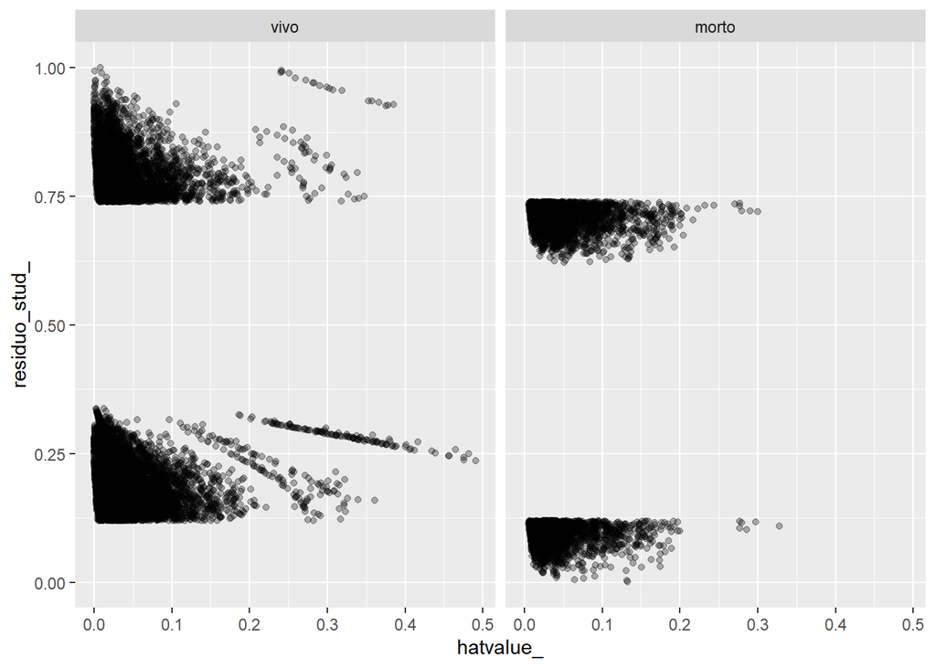

```r
ggplot(influ_df[(cluster  != 0)]) +
  geom_point(aes(x = hatvalue_,
                 y=residuo_stud_),
             alpha = 0.3)  + guides(color=guide_legend(title="Desfecho")) +
    facet_wrap(factor(as.integer(predict(log_reg,
                       comorbidade_regressao_simples[(cluster  != 0)],
                       type = "response") > limiar),levels = c(0,1), labels = c("vivo","morto")))
```

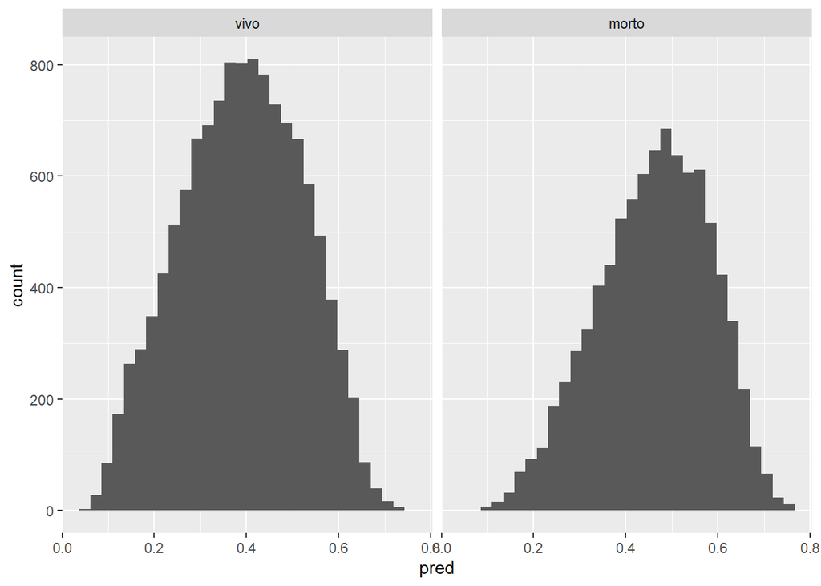

```r
ggplot(data.table(pred = predict(log_reg,comorbidade_regressao_simples,type = "response"),
                real = comorbidade_regressao_simples$obito_pre)) + geom_histogram(aes(x = pred)) + facet_wrap("real")
```

```r
#Verificando a quantidade de dados para cada conjunto de cluster
comorbidade_regressao_simples[,.N,by=.(cluster)]
```

| cluster | N |
| --- | --- |
| 1 | 11905 |
| 2 | 8693 |
| 3 | 119 |
| 0 | 39 |
| 4 | 136 |
| -1 | 58 |
| -2 | 19 |

## Inclusão dos clusters no modelo de regressão

Os clusters 1 e 2 são os mais populosos, por isso, vamos fazer uma redução nesses casos

```r
perc_reducao <- 0.7

gera_ind_amostra_cluster <- function(df,perc_red){
      df[,index := 1:nrow(df)]

      ind1 <- createDataPartition(df[cluster == 1]$index,p=1-perc_red,list=F)
      ind2 <- createDataPartition(df[cluster == 2]$index,p=1-perc_red,list=F)
      indn <- df[cluster != 1 & cluster != 2]$index
      return(c(df[cluster == 1,][ind1]$index,
               df[cluster == 2,][ind2]$index,
               indn))
}
ind_amostra_cluster <- gera_ind_amostra_cluster(comorbidade_regressao_simples,perc_reducao)
amostra_cluster <- comorbidade_regressao_simples[ind_amostra_cluster,]
influ_df_amostra_cluster <- influ_df[ind_amostra_cluster,]

influ_df_amostra_cluster[,.N,by=.(cluster)]
```

| cluster | N |
| --- | --- |
| 1 | 3573 |
| 2 | 2609 |
| 3 | 119 |
| 0 | 39 |
| 4 | 136 |
| -1 | 58 |
| -2 | 19 |

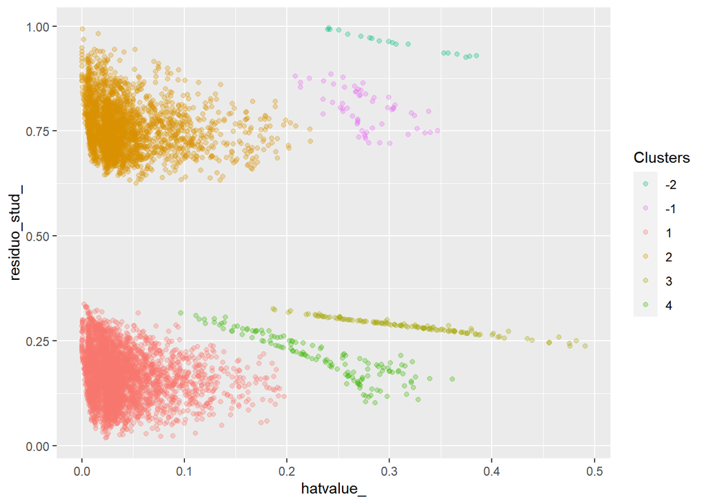

```r
ggplot(influ_df_amostra_cluster[(cluster != 0)]) +
  geom_point(aes(x = hatvalue_, y=residuo_stud_, color = as.factor(cluster)),alpha = 0.3) +
    scale_color_manual(values = c(cores[5],cores[9],cores[1],cores[2],cores[3],cores[4])) +
       guides(color=guide_legend(title="Clusters"))
```

Clusterização dos dados

```r
dissimilaridade <- daisy(x = amostra_cluster[,-c("cluster","obito_pre")],metric = "gower")
if(length(list.files("../data/interim/clusterizacao_r/")) == 0){
  clusterizacao_ward <- agnes(dissimilaridade, method = "ward")
  clusterizacao_average <- agnes(dissimilaridade, method = "average")
  clusterizacao_complete <- agnes(dissimilaridade, method = "complete")
  clusterizacao_single <- agnes(dissimilaridade, method = "single")

  saveRDS(clusterizacao_ward,file = "../data/interim/clusterizacao_r/clusterizacao_ward.RData")
  saveRDS(clusterizacao_average,file = "../data/interim/clusterizacao_r/clusterizacao_average.RData")
  saveRDS(clusterizacao_complete,file = "../data/interim/clusterizacao_r/clusterizacao_complete.RData")
  saveRDS(clusterizacao_single,file = "../data/interim/clusterizacao_r/clusterizacao_single.RData")
}else{
  clusterizacao_ward <- readRDS("../data/interim/clusterizacao_r/clusterizacao_ward.RData")
  clusterizacao_average <- readRDS("../data/interim/clusterizacao_r/clusterizacao_average.RData")
  clusterizacao_complete <- readRDS("../data/interim/clusterizacao_r/clusterizacao_complete.RData")
  clusterizacao_single <- readRDS("../data/interim/clusterizacao_r/clusterizacao_single.RData")
}
```

Apresentação dos dendogramas

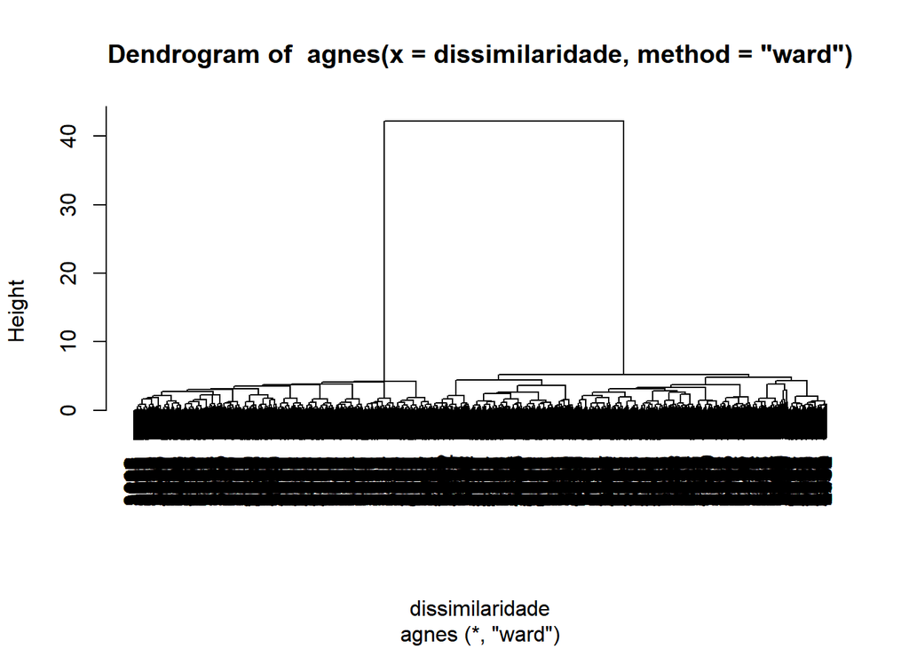

```r
pltree(clusterizacao_ward)
```

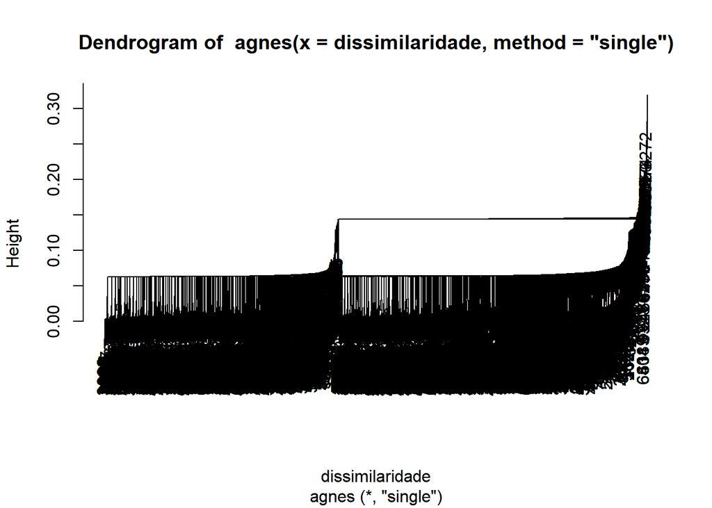

```r
pltree(clusterizacao_single)
```

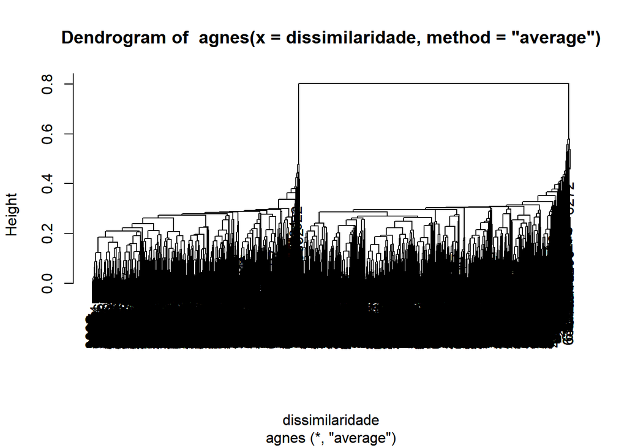

```r
pltree(clusterizacao_average)
```

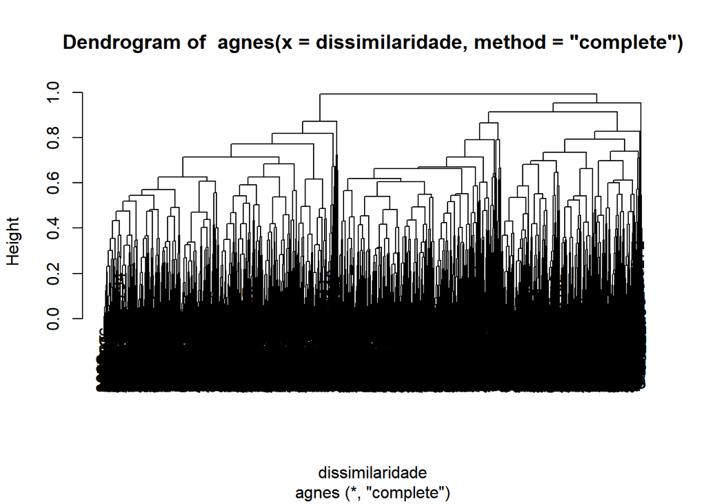

```r
pltree(clusterizacao_complete)
```

O dendograma que apresenta a maior homogeneidade (níveis mais altos na hierarquia apresentam um número razoável de registros) dentro do dendograma o método ward. Vamos utilizá-lo

```r
influ_df_amostra_cluster$agnes_ <- cutree(clusterizacao_ward,k=40)

influ_df_amostra_cluster[,.N,by = .(agnes_),
                        ][,.(agnes_,perc_pontos = 100*N/sum(N))]
```

| agnes_ | perc_pontos |
| --- | --- |
| 1 | 2.9299557 |
| 2 | 3.8913475 |
| 3 | 3.6929651 |
| 4 | 3.9218678 |
| 5 | 2.2890279 |
| 6 | 2.0601251 |
| 7 | 3.5251030 |
| 8 | 3.2656798 |
| 9 | 1.9685640 |
| 10 | 1.8159622 |

[output cut: 30 more lines]

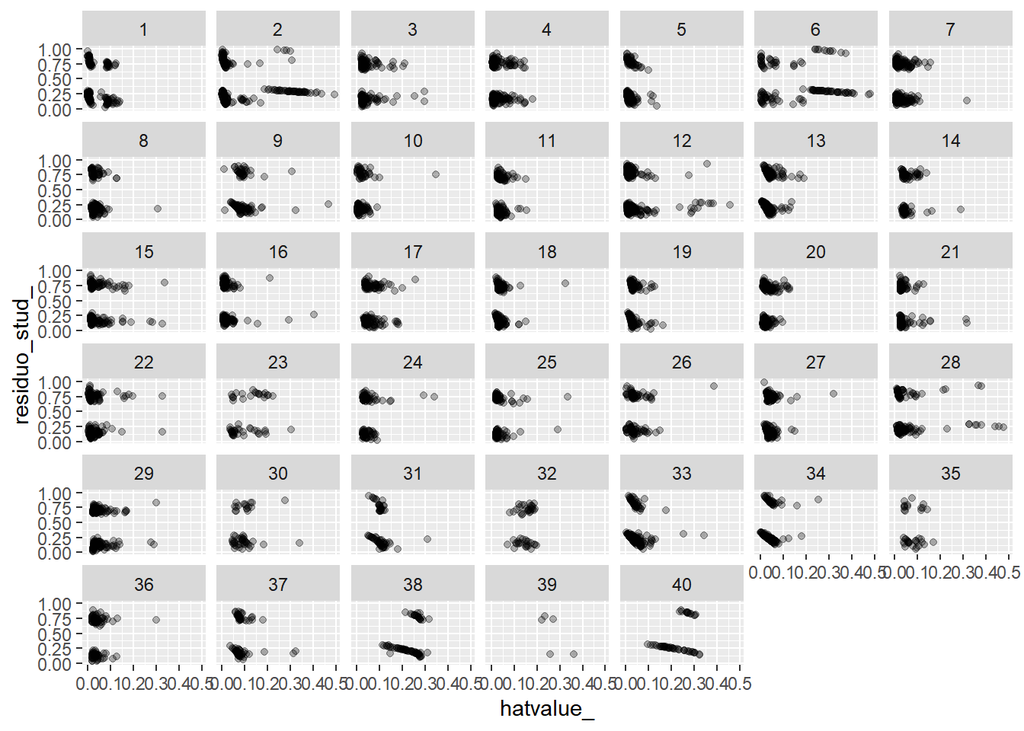

```r
ggplot(influ_df_amostra_cluster[(cluster != 0)]) +
  geom_point(aes(x = hatvalue_, y=residuo_stud_),alpha = 0.3) +
       guides(color=guide_legend(title="Clusters")) +  facet_wrap("agnes_")
```

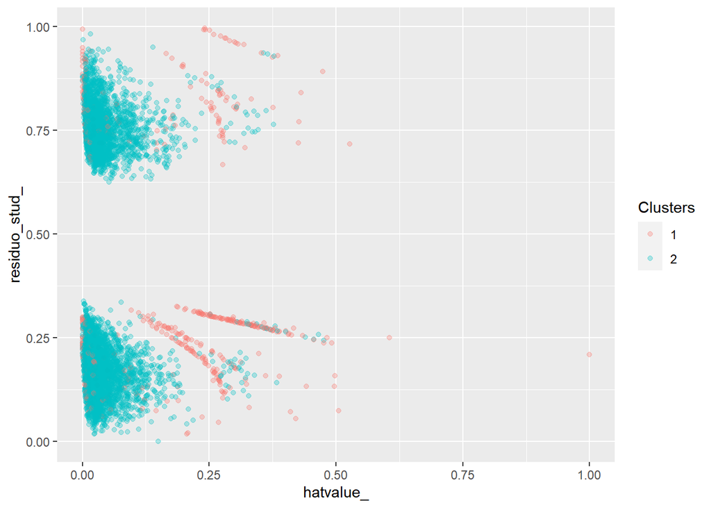

```r
knn_prediction <- function(dataset_treino,dataset_teste,label,k=3){

  distancia <- as.matrix(daisy(rbind(dataset_treino,dataset_teste),metric = "gower"))

  return(knn_test_function(dataset_treino,dataset_teste,distancia,label,k=k))
}

rotulo1 <- fifelse(influ_df_amostra_cluster$agnes_ == 2 |
                     influ_df_amostra_cluster$agnes_ == 6 |
                     influ_df_amostra_cluster$agnes_ >= 38,
                   1,
                   2)
result_knn <- knn_prediction(amostra_cluster[,-c("cluster","obito_pre")],
               amostra_cluster[,-c("cluster","obito_pre")],
               rotulo1
               )

ggplot(influ_df_amostra_cluster) +
  geom_point(aes(x = hatvalue_, y=residuo_stud_, color = as.factor(result_knn)),alpha = 0.3) +
       guides(color=guide_legend(title="Clusters"))
```

Aparentemente, realizar a clusterização e aplicar um kNN aos clusters e usar a predição do kNN como uma variável preditora da regressão logística reduziu as diferenças dentro da base de treino

Para a modelagem, já sabemos que a amostra possui o *outlier*. Vamos removê-los antes da modelagem

```r
amostra_cluster[,cluster := NULL]
amostra_cluster[,agnes_ := as.factor(rotulo1)]
amostra_cluster[,index := NULL]

#Removendo os outliers
amostra_cluster_sem_outlier <- amostra_cluster[-amostra_cluster[,.I[puerpera_pre == 'sim' & sindrome_de_down_pre == 'sim']]]

log_reg_clust <- glm(obito_pre ~ .,data = amostra_cluster_sem_outlier,family = "binomial")
grafico_influencia(log_reg_clust,size = F)
```

```
## $df_influencia
##       residuo_stud    hatvalue         cook
##    1:   -0.7027283 0.001289911 1.206327e-05
##    2:   -0.7569121 0.003244158 3.602564e-05
##    3:   -0.7916958 0.001314135 1.615045e-05
##    4:   -0.7950803 0.003352780 4.172860e-05
##    5:   -0.6544543 0.001301313 1.037774e-05
##   ---
## 6547:    1.5313701 0.008868192 6.616007e-04
## 6548:   -1.0618564 0.010276385 2.624301e-04
## 6549:   -0.7319630 0.012653562 1.318104e-04
## 6550:   -0.5584948 0.008173845 4.652243e-05
## 6551:   -0.8757122 0.007766813 1.221860e-04
##
## $plot
```

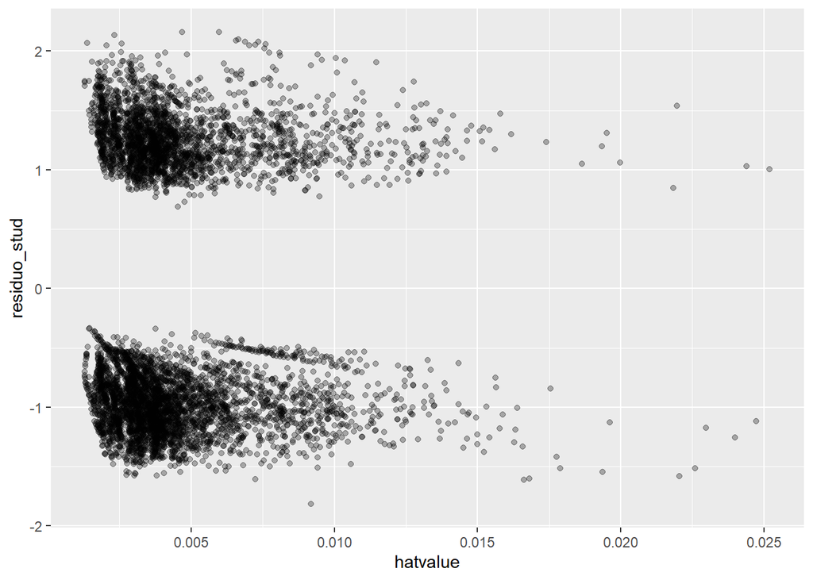

Vejamos se isso trás ganhos na predição

```r
rotulo_teste <- lapply(seq(from=0,to=ceiling(nrow(teste)/50)),function(x){
  #separando em amostras de 50
  seq_treino = seq(from=1,to=50) + (50*x)
  knn_prediction(dataset_treino = amostra_cluster[,-c("obito_pre","agnes_")],
                 dataset_teste = teste[seq_treino,-c("obito_pre")],
                 label = rotulo1)
  })
rotulo_teste_ <-unlist(rotulo_teste)[1:nrow(teste)]
```

Mesmo fazendo a adição dos clusters, o resultado ainda não foi tão satisfatório

```r
teste_cluster <- copy(teste)
teste_cluster$agnes_ <- as.factor(rotulo_teste_)
matriz_confusao(teste_cluster,log_reg_clust)
```

```
## Confusion Matrix and Statistics
##
##           Reference
## Prediction vivo morto
##      vivo  3795  2046
##      morto 1414  1731
##
##                Accuracy : 0.615
##                  95% CI : (0.6048, 0.625)
##     No Information Rate : 0.5797
##     P-Value [Acc > NIR] : 5.507e-12
##
##                   Kappa : 0.1912
##
##  Mcnemar's Test P-Value : < 2.2e-16
##
##             Sensitivity : 0.4583
##             Specificity : 0.7285
##          Pos Pred Value : 0.5504
##          Neg Pred Value : 0.6497
##               Precision : 0.5504
##                  Recall : 0.4583
##                      F1 : 0.5001
##              Prevalence : 0.4203
##          Detection Rate : 0.1926
##    Detection Prevalence : 0.3500
##       Balanced Accuracy : 0.5934
##
##        'Positive' Class : morto
##
```

```r
calcula_roc(df = teste_cluster,modelo = log_reg_clust)
```

```
## [1] "AUC =  0.648"
```

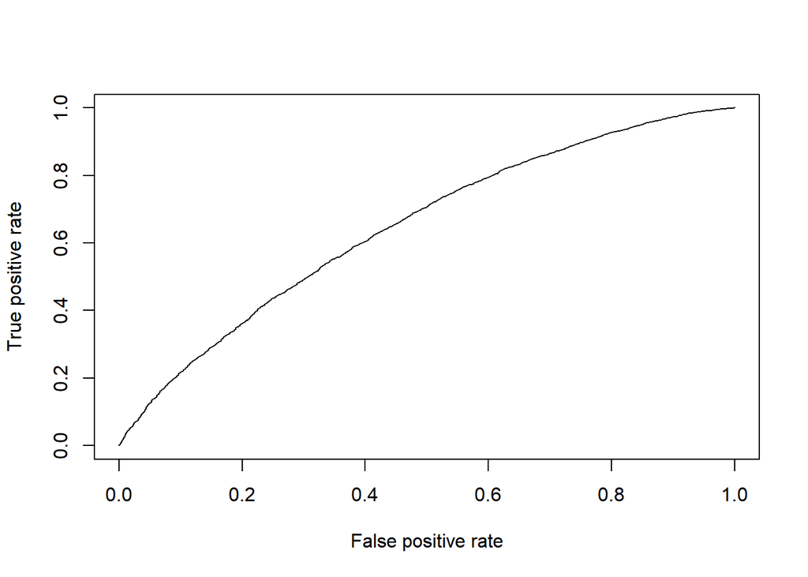

## Análise das estatísticas básicas dos clusters

Vamos avaliar separadamente os dados (uma análise exploratoria) dos grupos obtidos pelo DBScan

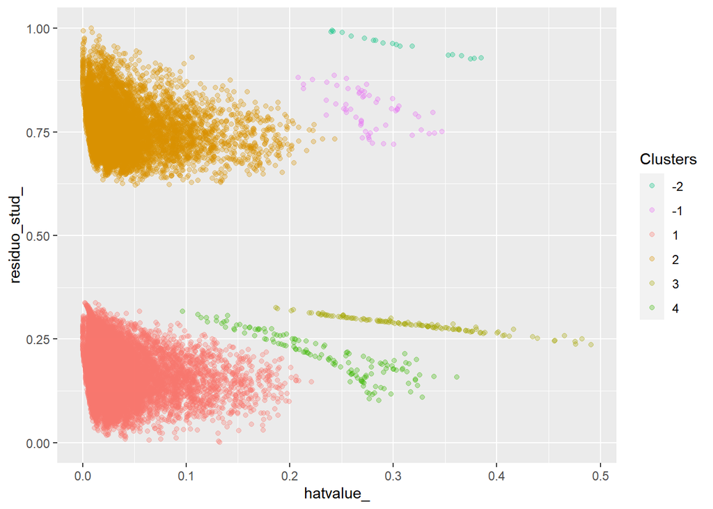

```r
ggplot(influ_df[(cluster != 0)]) +
  geom_point(aes(x = hatvalue_, y=residuo_stud_, color = as.factor(cluster)),alpha = 0.3) +
    scale_color_manual(values = c(cores[5],cores[9],cores[1],cores[2],cores[3],cores[4])) +
       guides(color=guide_legend(title="Clusters"))
```

```r
describe_clusters <- function(df,rotulo,modelo,threshold = 0.5,by="cluster"){
    df[,`:=`(cluster = as.factor(rotulo),
             predicao  = factor(fifelse(predict(modelo,df,type = "response") > threshold,1,0),
                                levels = c(0,1),
                                labels = c("vivo","morto"))),
      ][,acertou := predicao == obito_pre]

    colunas_pre <- names(df)[grep("pre",names(df))]
    #Removendo as colunas idade e obito
    colunas_fator_considerar <- colunas_pre[which(colunas_pre != "idade_pre" & colunas_pre != "obito_pre")]
    #vamos montar um dataset com as contagens de cada coluna
    estatisticas_fator <- Reduce(f = function(x,y){
                                          return(rbind(x,y))
                                                  },
                                 x = lapply(colunas_fator_considerar, function(x){
                                      d <- dcast.data.table(data = df,
                                                            formula = as.formula(paste(x,by,sep = " ~ ")),
                                                            fun.aggregate = length)
                                      names(d)[1] <- "variavel"
                                      d[,variavel := paste(x,variavel,sep="_")]
                                      return(d)
                                 }))

    #Distribuição dos desfechos por cluster
    volume_mortes <- dcast.data.table(data = df[,.N,by=c(by,'obito_pre')],
                     formula = as.formula(paste("obito_pre",by,sep=" ~ ")),value.var = "N",fill=0)


    names(volume_mortes)[1] <- "variavel"
    volume_mortes[,variavel := paste("volume",variavel,sep="_")]


    #Acuracia
    acu <- dcast.data.table(data = df[,.N,by=c(by,"obito_pre","acertou")],
                            formula = as.formula(paste("acertou + obito_pre",by,sep = " ~ ")),value.var = "N",fill=0)
    acu[,variavel := paste(acertou,obito_pre,sep = "_"),
       ][,`:=`(acertou=NULL,
               obito_pre = NULL)]

    acu <- acu[,.SD,.SDcols = c(ncol(acu),1:(ncol(acu)-1))]

    #Estatísticas da idade
    estatistica_idade <- dcast(melt(df[,.(idade_pre_media = mean(idade_pre),
                                          idade_pre_desvio = sd(idade_pre)),by = by],
                                    id.vars = by,
                                    variable.name = "variavel"),
                               variavel ~ cluster)


    #dando o devido nome as colunas
    names(estatistica_idade)[-1] <- paste0(by,sort(unique(rotulo)))
    names(estatisticas_fator)[-1] <- paste0(by,sort(unique(rotulo)))
    names(volume_mortes)[-1] <- paste0(by,sort(unique(rotulo)))
    names(acu)[-1] <- paste0(by,sort(unique(rotulo)))


    return(rbindlist(list(estatisticas_fator,volume_mortes,acu,estatistica_idade),use.names = T))

}

descritivo <- describe_clusters(df = comorbidade_regressao_simples,
                                rotulo = influ_df$cluster,
                                modelo = log_reg)
descritivo[,-c("cluster0"),
           ][,.(variavel,`cluster-2`,`cluster-1`,cluster2, cluster1,cluster3,cluster4)]
```

| variavel | cluster-2 | cluster-1 | cluster2 | cluster1 | cluster3 | cluster4 |
| --- | --- | --- | --- | --- | --- | --- |
| cs_sexo_pre_feminino | 19.0000000 | 25.0000000 | 4049.0000000 | 5904.0000000 | 119.0000000 | 61.000000 |
| cs_sexo_pre_masculino | 0.0000000 | 33.0000000 | 4644.0000000 | 6001.0000000 | 0.0000000 | 75.000000 |
| asma_pre_ignorado | 4.0000000 | 19.0000000 | 3683.0000000 | 4782.0000000 | 48.0000000 | 49.000000 |
| asma_pre_não | 15.0000000 | 33.0000000 | 4449.0000000 | 5669.0000000 | 61.0000000 | 79.000000 |
| asma_pre_sim | 0.0000000 | 6.0000000 | 561.0000000 | 1454.0000000 | 10.0000000 | 8.000000 |
| cardiopatia_pre_ignorado | 5.0000000 | 13.0000000 | 1764.0000000 | 2880.0000000 | 46.0000000 | 37.000000 |
| cardiopatia_pre_não | 14.0000000 | 18.0000000 | 2110.0000000 | 3229.0000000 | 60.0000000 | 55.000000 |
| cardiopatia_pre_sim | 0.0000000 | 27.0000000 | 4819.0000000 | 5796.0000000 | 13.0000000 | 44.000000 |
| diabetes_pre_ignorado | 4.0000000 | 13.0000000 | 2220.0000000 | 3350.0000000 | 45.0000000 | 43.000000 |
| diabetes_pre_não | 14.0000000 | 28.0000000 | 2875.0000000 | 4060.0000000 | 58.0000000 | 60.000000 |

[output cut: 41 more lines]

```r
#Percentual que compõe cada variável categórica para cada grupo
descritivo_perc <- function(descr,
                            ordem_colunas = NULL,
                            df_original = comorbidade_regressao_simples,
                            rotulos_clusters = comorbidade_regressao_simples$cluster){

  df_original[,cluster := as.factor(rotulos_clusters)]
  df <- cbind(descr[,.(variavel)],
              descr[,Map(function(x,y){round(100*x/y,2)},.SD,
                      df_original[,.N,by=.(cluster),
                                 ][order(cluster)]$N),.SDcols = -c("variavel")])

  if(!is.null(ordem_colunas)){
    df <- df[,.SD,.SDcols = ordem_colunas]
  }

  return (df)
}

descritivo_perc(descritivo,c("variavel","cluster-2","cluster-1","cluster2","cluster1","cluster3","cluster4"))
```

| variavel | cluster-2 | cluster-1 | cluster2 | cluster1 | cluster3 | cluster4 |
| --- | --- | --- | --- | --- | --- | --- |
| cs_sexo_pre_feminino | 100.00 | 43.10 | 46.58 | 49.59 | 100.00 | 44.85 |
| cs_sexo_pre_masculino | 0.00 | 56.90 | 53.42 | 50.41 | 0.00 | 55.15 |
| asma_pre_ignorado | 21.05 | 32.76 | 42.37 | 40.17 | 40.34 | 36.03 |
| asma_pre_não | 78.95 | 56.90 | 51.18 | 47.62 | 51.26 | 58.09 |
| asma_pre_sim | 0.00 | 10.34 | 6.45 | 12.21 | 8.40 | 5.88 |
| cardiopatia_pre_ignorado | 26.32 | 22.41 | 20.29 | 24.19 | 38.66 | 27.21 |
| cardiopatia_pre_não | 73.68 | 31.03 | 24.27 | 27.12 | 50.42 | 40.44 |
| cardiopatia_pre_sim | 0.00 | 46.55 | 55.44 | 48.69 | 10.92 | 32.35 |
| diabetes_pre_ignorado | 21.05 | 22.41 | 25.54 | 28.14 | 37.82 | 31.62 |
| diabetes_pre_não | 73.68 | 48.28 | 33.07 | 34.10 | 48.74 | 44.12 |

[output cut: 41 more lines]

# Criação do modelo 2

Pela análise acima, vemos que existe uma relação muito próxima do sexo entre os cluster -2 e 3 e -1 e 4. Dessa forma, façamos um teste e removamos eles do nosso modelo e vejamos novamente o gráfico de influência

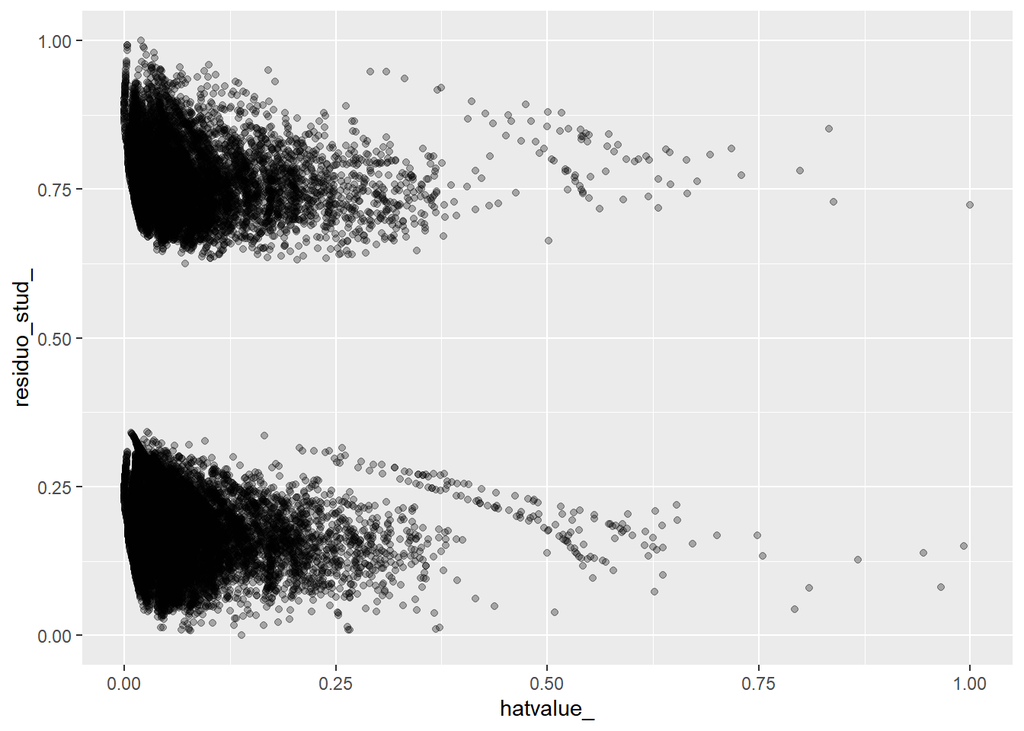

```r
#O registro 17963 já é conhecido que deve ser errado. Fazendo uma nova busca, encontramos que o registro 17346 também está errado, pois foi registrado uma paciente com síndrome de down e puérpera. Portanto, vamos remover esses registros na atualização do modelo

log_reg_sem_sexo <- update(log_reg,
                           formula = obito_pre ~ . - puerpera_pre - cs_sexo_pre,
                           subset = -linhas_outlier)
result <- grafico_influencia(log_reg_sem_sexo)
influ_df2 <- result$df_influencia

influ_df2[,`:=`(hatvalue_ = normalize(hatvalue),residuo_stud_ = normalize(residuo_stud))]
ggplot(influ_df2) + geom_point(aes(x = hatvalue_, y=residuo_stud_),alpha = 0.3)
```

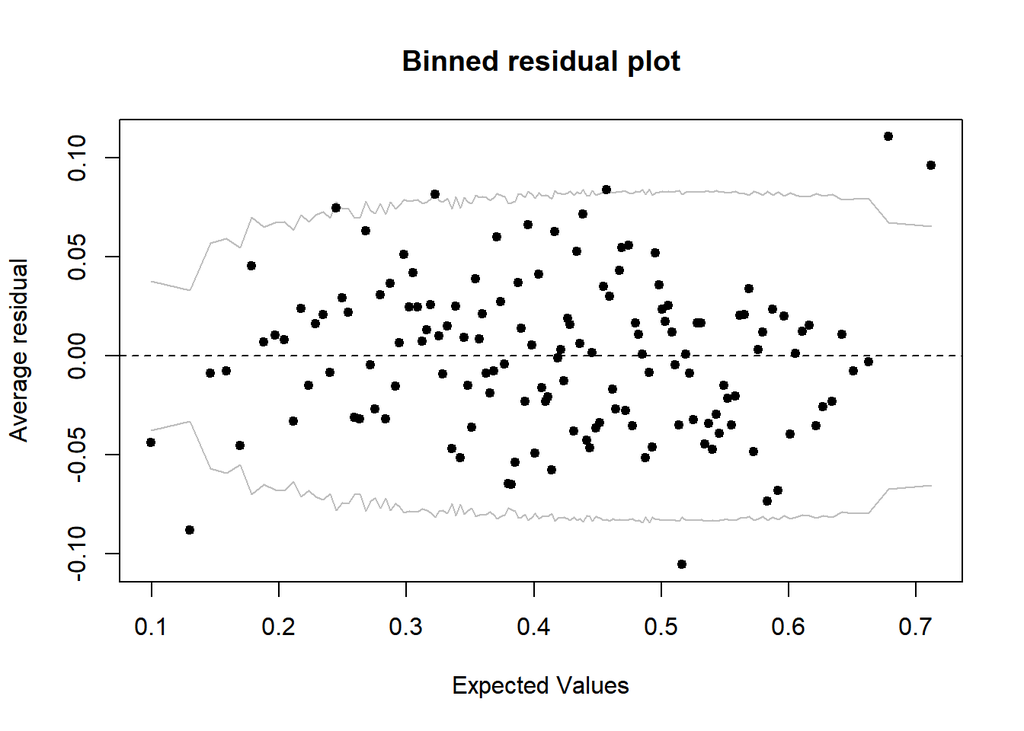

```r
arm::binnedplot(log_reg_sem_sexo$fitted.values,residuals(log_reg_sem_sexo,type = "response"))
```

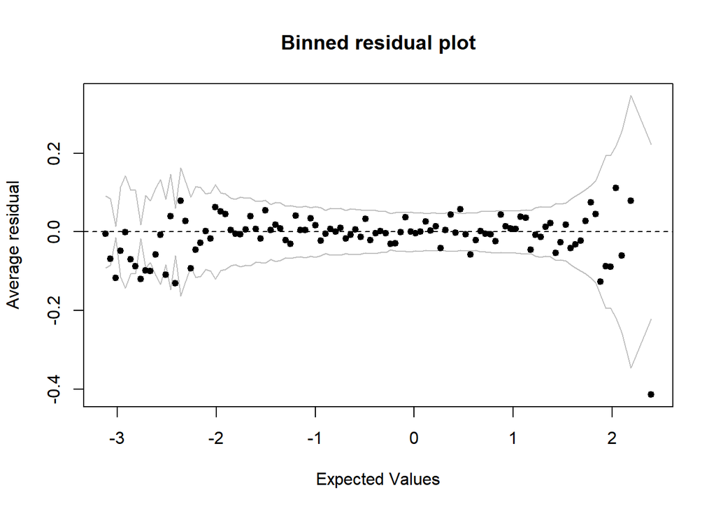

```r
arm::binnedplot(comorbidade_regressao_simples[-linhas_outlier,]$idade_pre,residuals(log_reg_sem_sexo,type = "response"),nclass = 2000)
```

Com essa nova abordagem, removemos 2 clusters. Vejamos o comportamento desse modelo

```r
#Em cima dos dados de teste, tivemos uma pequena melhora nos resultados (61.5% -> 61.8%)
matriz_confusao(teste,log_reg_sem_sexo)
```

```
## Confusion Matrix and Statistics
##
##           Reference
## Prediction vivo morto
##      vivo  4045  2268
##      morto 1164  1509
##
##                Accuracy : 0.6181
##                  95% CI : (0.6079, 0.6281)
##     No Information Rate : 0.5797
##     P-Value [Acc > NIR] : 6.98e-14
##
##                   Kappa : 0.1834
##
##  Mcnemar's Test P-Value : < 2.2e-16
##
##             Sensitivity : 0.3995
##             Specificity : 0.7765
##          Pos Pred Value : 0.5645
##          Neg Pred Value : 0.6407
##               Precision : 0.5645
##                  Recall : 0.3995
##                      F1 : 0.4679
##              Prevalence : 0.4203
##          Detection Rate : 0.1679
##    Detection Prevalence : 0.2975
##       Balanced Accuracy : 0.5880
##
##        'Positive' Class : morto
##
```

```r
calcula_roc(df = teste,modelo = log_reg_sem_sexo)
```

```
## [1] "AUC =  0.65"
```

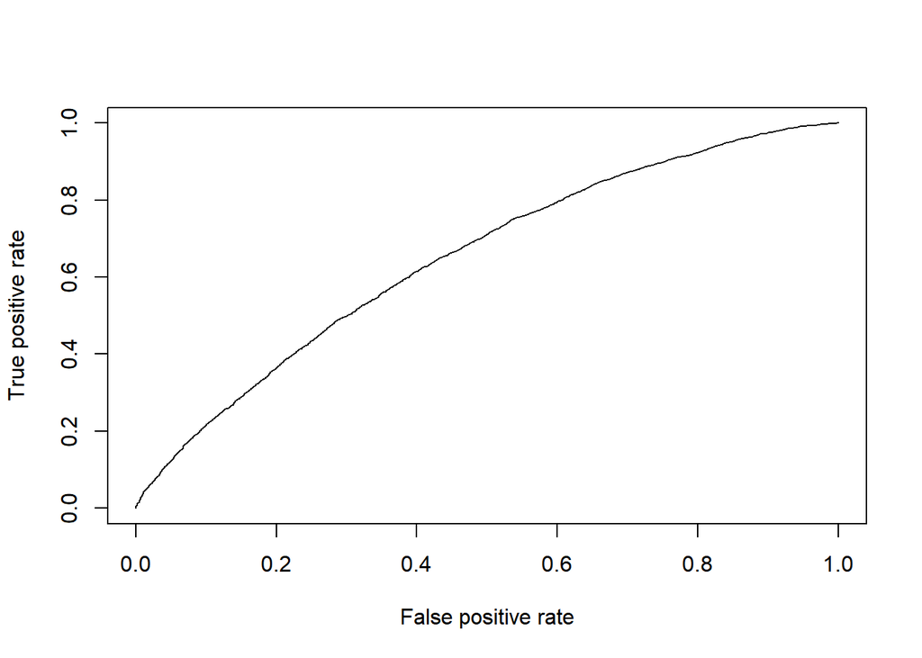

# Clusterização dos dados do gráfico de resíduo por influência

Façamos o procedimento novamente, para tentar identificar esses 2 clusters extras

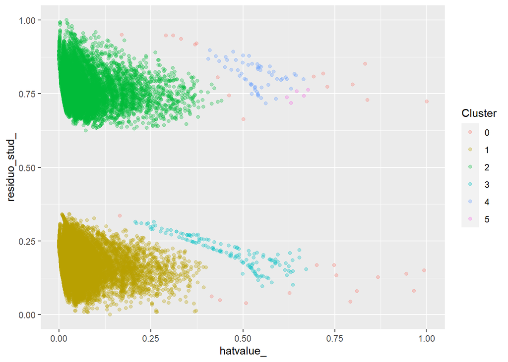

```r
db_result2 <- dbscan(x = as.matrix(influ_df2[,.(hatvalue_,residuo_stud_)]), eps = 0.0375)
ggplot(influ_df2) + geom_point(aes(x = hatvalue_, y=residuo_stud_, color = as.factor(db_result2$cluster)),alpha = 0.3) +
  guides(color=guide_legend(title="Cluster"))
```

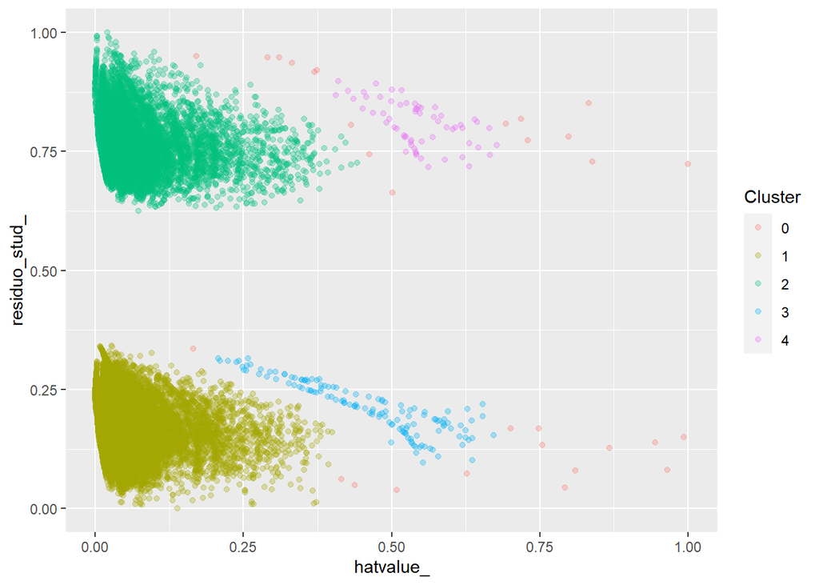

```r
influ_df2$cluster <- db_result2$cluster
influ_df2[,cluster := as.factor(fifelse(cluster == 5,4,cluster))]
ggplot(influ_df2) + geom_point(aes(x = hatvalue_, y=residuo_stud_, color = cluster),alpha = 0.3) +
  guides(color=guide_legend(title="Cluster"))
```

```r
descritivo2 <- describe_clusters(df = comorbidade_regressao_simples[-linhas_outlier,-c('puerpera_pre','cs_sexo_pre')],
                                  rotulo = influ_df2$cluster,
                                  modelo = log_reg_sem_sexo)
descritivo2[,c("variavel","cluster1","cluster3","cluster4","cluster2")]
```

| variavel | cluster1 | cluster3 | cluster4 | cluster2 |
| --- | --- | --- | --- | --- |
| asma_pre_ignorado | 4831.0000000 | 49.000000 | 20.0000000 | 3688.0000000 |
| asma_pre_não | 5734.0000000 | 78.000000 | 35.0000000 | 4464.0000000 |
| asma_pre_sim | 1464.0000000 | 9.000000 | 6.0000000 | 559.0000000 |
| cardiopatia_pre_ignorado | 2926.0000000 | 37.000000 | 14.0000000 | 1770.0000000 |
| cardiopatia_pre_não | 3290.0000000 | 55.000000 | 19.0000000 | 2123.0000000 |
| cardiopatia_pre_sim | 5813.0000000 | 44.000000 | 28.0000000 | 4818.0000000 |
| diabetes_pre_ignorado | 3395.0000000 | 44.000000 | 14.0000000 | 2225.0000000 |
| diabetes_pre_não | 4119.0000000 | 60.000000 | 28.0000000 | 2887.0000000 |
| diabetes_pre_sim | 4515.0000000 | 32.000000 | 19.0000000 | 3599.0000000 |
| doenca_hematologica_pre_ignorado | 5230.0000000 | 49.000000 | 22.0000000 | 3685.0000000 |

[output cut: 36 more lines]